# Homework 5

## Problem 1. A Data Scientist Referees Ping Pong (8pts total)

The game is Ping Pong. Players grab their paddles and hit the ping pong ball back and forth scoring points one at a time. The game continues until one player reaches 21 points, and at that point the game ends unless the point difference is less than 2. If it is less than 2 the game continues until one player wins by 2.

Suppose Athena and Bacchus play and Bacchus wins 21 to 15. Bacchus is super excited but Athena says that they should have a rematch, because she’s sure that Bacchus is not better than her, it was just a fluke.

Time for a Data Scientist to settle this dispute. We must consider two hypotheses. The null hypothesis is that they are equally skilled - thus for each point scored the probability it goes to the ultimate winner is $0.50$ (this is basically what Athena is claiming). The alternative is that Bacchus truly is more skilled, and the probability is greater than $0.50$ (the winner actually has more skill, and doesn’t win purely by chance).

Create a Monte Carlo simulation of a game. Use the point difference at game end as the test statistic.

1. (4 points) Create a function called `playPingPong` which simulates a single game of Ping Pong with equally skilled players. Remember the logic : points are given to players A or B with equal chance, and that continues until (1) the max score >= 21 and (2) the difference between scores >=2. Have the function return the point difference.

```r
playPingPong <- function(scoreTrigger = 21, winMargin=2, probPlayerA=0.5){
  #initialize a score vector to be 0,0

  #repeat while the winning condition has not been reached
  #i.e. repeat while max score < 21 or point difference < 2
  playerA = 0
  playerB = 0
  while((playerA < 21 && playerB < 21)) {
    point = rbinom(1, 1, probPlayerA)
    playerA = if(point == 0)  playerA else playerA + 1
    playerB = if(point == 0)  playerB + 1 else playerB
  }
  while (abs(playerA - playerB) < 2) {
    point = rbinom(1, 1, probPlayerA)
    playerA = if(point == 0)  playerA else playerA + 1
    playerB = if(point == 0)  playerB + 1 else playerB
  }
  return(playerA - playerB)

    #Assign a point to player 1 or 2 randomly

  #return the point difference
}
```

2. (2 points) Perform the Monte Carlo test; simulate 1000 (or more) games with equally skilled players. Look at the distribution of point differences, and compare the observed point difference to this distribution. What is the *p*-value of the observed point difference.

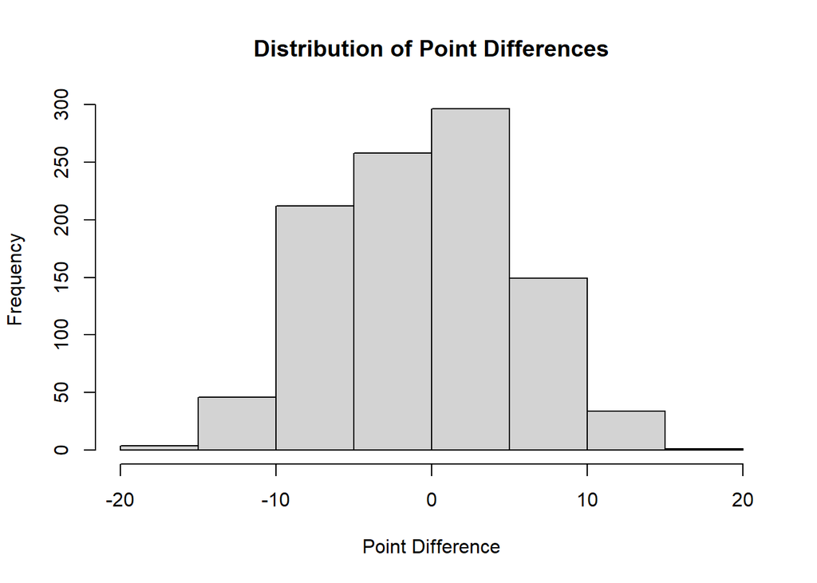

```r
#TODO: Enter Code Here
reps = replicate(1000, playPingPong())
hist(reps, main="Distribution of Point Differences", xlab="Point Difference")
```

```r
mean(reps)
```

```
## [1] -0.195
```

The *p* value:

```r
mean(reps <= -6)
```

```
## [1] 0.199
```

3. (2 points) How do you conclude? Is this one game sufficient evidence that Bacchus is the superior Ping Pong Player?

If we set $\alpha = .05$, there is not statistically significant evidence that Bacchus is a suprior player, and we accept the null hypothesis that both players are evenly matched.

## Problem 2: Quality or Quantity? (6pts total)

Marcio Ranchello (fictional) is a prolific architect who has won many accolades. For example, in the ranking of “Best 10 designs of 2023”, 4 of the 10 designs are from Marcio Ranchello. The authors of the ranking report suggest that this is evidence of his greatness. However, you notice that among the 150 buildings considered in the rankings, 30 of them were designed by Marcio. Indeed, Marcio leads a big architecture firm that has been extremely active in designing new buildings.

What do you think? Is the ranking evidence of the quality of his work, or a consequence of the quantity of his designs?

Take the null hypothesis to be that any of the 150 considered buildings could be included in the top 10 with equal likelihood. How likely under this model would we see 4 (or more) of Ranchello’s buildings in the top 10? What do you conclude?

```r
print(1 - phyper(3, 30, 120, 10))
```

```
## [1] 0.1135089
```

There is a $\approx$ 11% chance of 4 or more of Ranchello’s buildings being in the top 10 assuming each building has equal likelihood of being in the top 10.

Proceed by treating this as a formal hypothesis test. Define the null and alternative hypotheses, define your test statistic, produce a distribution of simulated test statistics from the null model and finish by calculating a p-value and providing your own interpretation.

$H_0 = \text{all buildings equally likely to be in the top 10}$

$H_a = \text{marcio's buildings are more likely to be in the top 10}$

The test statistic will be the number of marcio’s buildings in the top 10.

Calculation of P-value using simulation:

```r
rankings = c(replicate(30, 1), replicate(120, 0))
reps = replicate(1e5, sum(sample(rankings)[1:10]))
mean(reps >= 4)
```

```
## [1] 0.11423
```

There is not statistically significant since the p value is well above the threshold of $.05$, thus we accept the null hypothesis and conclude there is no statistically significant evidence that Marcio’s buildings are more likely to be in the top 10.

## Problem 3: Permutation testing (8pts)

Below are data arising from a (fictionalized) data source: the number of defects per day on an assembly line before and after installation of a new torque converter (this is a totally fictional “part” of an assembly line–just treat these as “control” and “treatment” groups, respectively).

```r
before = c(4,5,6,3,6,3,4,5,5,3,4,6,4,6,3,4,2,2,0,7,5,8,4,5,1,4,4,8,2,3)
after  = c(3,2,4,3,7,5,5,2,2,4,5,2,2,6,1,5,6,3,2,3,7,3,4,5,4,2,2,6,7,8)
```

1. (4 points) Use a permutation test to assess the claim that installation of the new part *changed* the prevalence of defects. That is, test the null hypothesis that the distribution of defects is the same before and after installation of the new part. Produce a p-value and interpret the results of your test in context.

```r
set.seed(123)
dist = c(before, after)
length(dist)
```

```
## [1] 60
```

```r
reps = replicate(1e5, sample(dist)) #will be a matrix w/ each column as a permutation
before_reps = reps[1:length(before), ] #1st half will be before installing
after_reps = reps[(length(before) + 1): length(dist),] #2nd half will be after installing
b4_mean = colMeans(before_reps)
after_mean = colMeans(after_reps)
mean(abs(b4_mean - after_mean) >= abs(mean(before) - mean(after))) #2-tailed, probability of simulated diff in averages diverging from observed
```

```
## [1] 0.73343
```

2. (4 points) Explain, briefly, what you did above and why. Imagine that you are trying to explain to someone who isn’t well versed in statistics what exactly you are doing in a permutation test. Explain your conclusion based on your test above. Three to five sentences should be plenty, but you are free to write as much or as little as you think is necessary to clearly explain your findings.

We are trying to find out if this new part reduced the prevalence of defects, this can be expressed as the difference of mean defects before the part was installed and after. Since we only care about the change of the avg number of defects, we will use the absolute difference to measure prevalence. To test if the part is really changing prevalence (opposed to randomly observing this effect), we will simulate additional data points by randomly shuffling all the before and after observations to see the likelihood of seeing our observed difference in means. Here we see the chance of getting an simulated prevalence greater than our observation is $\approx$ 73%, our threshold for random chance is 5%, so we accept the hypothesis that out observed difference in means was due to random chance.

## Problem 4: Memes (8pts)

The following question comes from Karl Rohe, who developed the very first version of this class. This question has been reproduced in nearly the exact original (very amusing) wording.

> **Memes, part 1** (Please forgive me. I drank too much coffee before writing this question.)

> In class thus far, there have been 416 comments posted in the bbcollaborate chat during class. An expert panel has judged 47 of these comments to be memes. The big-bad-deans say that they are concerned “if there is evidence that more than 10% of comments are memes.” So, this looks like bad news, 47/416>10%.

> Karl pleads with the deans: “Please, oh please, you big-bad-deans… Memeing is totally random.” (I don’t actually know what this notion of “random” means, but please just run with it for this question.) Then, along comes you, a trusty and dedicated 340 student. You say that “because we have only observed 416 comments, we don’t really know what the ‘true proportion’ of memes.”

> 4a: What would be a good distribution for the number of memes?

> We want to find if there is evidence that, out of $416$ comments, $ > .1$ are memes. There is a fixed number of trials, binary success and failure, and we have a hypothetical proportion. Choose $Binom(416, .1)$

> 4b: Using your distribution from 4a, test the null hypothesis that the ‘true proportion’ is actually 10%. It’s all up to you now… report the p-value

> This is equivalent to P[Binom(416, .1) >= 47]

Analytically:

```r
p_value = 1 - pbinom(46, size = 416, prob = 0.10)
print(p_value)
```

```
## [1] 0.2093049
```

Simulation:

```r
print(mean(rbinom(1e5, 416, .1) >= 47))
```

```
## [1] 0.21104
```

We conclude that there is not statistically significant evidence the true proportion of memes to comments is > 10% and accept the null hypothesis.

Hints:

- For 4a, there should be a (hopefully) fairly intuitive choice of random variable that makes sense here. Look at your list of random variables and ask yourself which of these makes the most sense.
- For 4b, you can use the built-in function in R to simulate observations according to your null. Remember that you **always simulate *assuming* the null hypothesis**. Make sure your choice of the necessary parameter(s) reflects this assumption.